# Applied Machine Learning Using mlr3

Hyperparameter Optimisation

Author

Paul Smith

Published

April 11, 2025

# Introduction and prerequisites

These notes mirror [Section 4](https://mlr3book.mlr-org.com/chapters/chapter4/hyperparameter_optimization.html) of *Applied Machine Learning Using mlr3 in R* (Becker, Schneider, and Fischer 2024).

Becker, Marc, Lennart Schneider, and Sebastian Fischer. 2024. “Hyperparameter Optimization.” In *Applied Machine Learning Using mlr3 in R*, edited by Bernd Bischl, Raphael Sonabend, Lars Kotthoff, and Michel Lang. CRC Press. https://mlr3book.mlr-org.com/hyperparameter_optimization.html.

**Parameter**

model coefficients or weights (or other information) that are determined by the learning algorithm based on the training data.

**Hyperparameter**

configures by the user and determine how the model will fit its parameters (*i.e.* how the model is built).[^1]

<sup>1</sup> For example, the number of trees in a random forest, penalty settings in support vectors machines *etc*

The aim of hyperparameter optimisation (model tuning) is to find the optimal configuration of hyperparameters of a machine learning algorithm for a given task. There is no closed-form representation here, so it relies on resampling with different configurations and choosing the configuration with the best performance.

**Tuner**

a hyperparameter optimisation method.

[figure not shown]

Representation of the hyperparameter optimization loop in mlr3tuning. Blue - Hyperparameter optimization loop. Purple - Objects of the tuning instance supplied by the user. Blue-Green - Internally created objects of the tuning instance. Green - Optimization Algorithm.

```r
library(mlr3)
library(mlr3viz)
library(mlr3learners)
library(mlr3data)
library(mlr3tuning)
library(mlr3tuningspaces)
library(e1071)
library(ggplot2)
library(patchwork)
library(data.table)
options(datatable.print.nrows = 20)
```

Suppress all messaging unless it’s a warning:[^2]

<sup>2</sup> The packages in `{mlr3}` that make use of optimization, i.e., `{mlr3tuning}` or `{mlr3fselec}`t, use the logger of their base package `{bbotk}`.

```r
lgr::get_logger("mlr3")$set_threshold("warn")
lgr::get_logger("bbotk")$set_threshold("warn")
```

## Structure

This article is structured as follows:

# Model Tuning

The `{mlr3}` ecosystem uses the `{mlr3tuning}` package (Becker et al. 2025) to perform hyperparameter optimisation, which has the R6 classes:

Becker, Marc, Michel Lang, Jakob Richter, Bernd Bischl, and Daniel Schalk. 2025. *Mlr3tuning: Hyperparameter Optimization for ’Mlr3’*. https://mlr3tuning.mlr-org.com.

- [TuningInstanceBatchSingleCrit](https://mlr3tuning.mlr-org.com/reference/TuningInstanceBatchSingleCrit.html): a tuning ‘instance’ that describes the optimisation problem and stores the results;
- [TunerBatch](https://mlr3tuning.mlr-org.com/reference/TunerBatch.html): used to configure and run optimisation algorithms.

In this section, we look at optimising an SVM classifier from [{e1071}](https://cran.r-project.org/web/packages/e1071/index.html) (Meyer et al. 2024) on `tsk("sonar")`.

Meyer, David, Evgenia Dimitriadou, Kurt Hornik, Andreas Weingessel, and Friedrich Leisch. 2024. *E1071: Misc Functions of the Department of Statistics, Probability Theory Group (Formerly: E1071), TU Wien*. https://CRAN.R-project.org/package=e1071.

## Learner and search space

First look at the learner’s possible hyperparameters to tune, using `$param_set`.

```r
as.data.table(lrn("classif.svm")$param_set)[,
  .(id, class, lower, upper, nlevels)]
```

```
                 id    class lower upper nlevels
             <char>   <char> <num> <num>   <num>
 1:       cachesize ParamDbl  -Inf   Inf     Inf
 2:   class.weights ParamUty    NA    NA     Inf
 3:           coef0 ParamDbl  -Inf   Inf     Inf
 4:            cost ParamDbl     0   Inf     Inf
 5:           cross ParamInt     0   Inf     Inf
 6: decision.values ParamLgl    NA    NA       2
 7:          degree ParamInt     1   Inf     Inf
 8:         epsilon ParamDbl     0   Inf     Inf
 9:          fitted ParamLgl    NA    NA       2
10:           gamma ParamDbl     0   Inf     Inf
11:          kernel ParamFct    NA    NA       4
12:              nu ParamDbl  -Inf   Inf     Inf
13:           scale ParamUty    NA    NA     Inf
14:       shrinking ParamLgl    NA    NA       2
15:       tolerance ParamDbl     0   Inf     Inf
16:            type ParamFct    NA    NA       2
```

**Search space (tuning space)**

the subset of hyperparameters that are chosen to tune.

Here, we will tune the numeric regularisation and kernel width hyperparameters `cost` and `gamma`.[^3]

<sup>3</sup> From the `svg()` [man page](https://www.rdocumentation.org/packages/e1071/versions/1.7-16/topics/svm), we can see:

- `cost`: cost of constraints violation (default: 1)—it is the ‘C’-constant of the regularization term in the Lagrange formulation.
- `gamma`: parameter needed for all kernels except linear (default: 1/(data dimension))

For numerical hyperparameters, we need to set a range of values of search over, which is done using `to_tune()`.

```r
learner = lrn("classif.svm",
  type  = "C-classification",
  kernel = "radial",
  cost  = to_tune(1e-1, 1e5),
  gamma = to_tune(1e-1, 1)
)
learner
```

```
<LearnerClassifSVM:classif.svm>: Support Vector Machine
* Model: -
* Parameters: cost=<RangeTuneToken>, gamma=<RangeTuneToken>,
  kernel=radial, type=C-classification
* Packages: mlr3, mlr3learners, e1071
* Predict Types:  [response], prob
* Feature Types: logical, integer, numeric
* Properties: multiclass, twoclass
```

## Terminator

Terminators are stored in the `mlr_terminators` dictionary and are constructed with the sugar function `trm()`.

Terminators available in `{mlr3tuning}`. For an up-to-date list, see the website.

| Terminator | Function Call and Default Parameters |
| --- | --- |
| Clock Time | `trm("clock_time")` |
| Combo | `trm("combo", any = TRUE)` |
| None | `trm("none")` |
| Number of Evaluations | `trm("evals", n_evals = 100, k = 0)` |
| Performance Level | `trm("perf_reached", level = 0.1)` |
| Run Time | `trm("run_time", secs = 30)` |
| Stagnation | `trm("stagnation", iters = 10, threshold = 0)` |

## Tuning instance with `ti`

**Tuning instance**

collects the tuner-agnostic information required to optimise a model (*i.e.* all information about the tuning process, except for the tuning algorithm itself).[^4]

<sup>4</sup> This includes the task to tune over, the learner to tune, the resampling method and measure used, and the terminator.

A tuning instance can be constructed explicitly with `ti()`, or the learner can be tuned with `tune()` (described in Section 2.6).

First, let’s constuct a single-objective tuning problem (*i.e.* tuning over one measure), by using `ti()` to create a `TuningInstanceBatchSingleCrit`. We will use three-fold CV and optimise the classification error measure. We will use the grid search tuner, so can use `trm("none")` as we want to iterate over the full grid without stopping too soon.

```r
tsk_sonar <- tsk("sonar")
learner <- lrn("classif.svm",
               cost = to_tune(1e-1, 1e5),
               gamma = to_tune(1e-1, 1),
               kernel = "radial",
               type = "C-classification"
               )

instance <- ti(
               task = tsk_sonar,
               learner = learner,
               resampling = rsmp("cv", folds = 3),
               measures = msr("classif.ce"),
               terminator = trm("none")
               )

instance
```

```
<TuningInstanceBatchSingleCrit>
* State:  Not optimized
* Objective: <ObjectiveTuningBatch:classif.svm_on_sonar>
* Search Space:
       id    class lower upper nlevels
   <char>   <char> <num> <num>   <num>
1:   cost ParamDbl   0.1 1e+05     Inf
2:  gamma ParamDbl   0.1 1e+00     Inf
* Terminator: <TerminatorNone>
```

## Tuner

Now we need to decide how to tune the model, which is done using a `Tuner` class.

Tuning algorithms available in `{mlr3tuning}`. For a complete list, see the [website](https://mlr-org.com/tuners.html).

| Tuner | Function Call | Package |
| --- | --- | --- |
| Random Search | `tnr("random_search")` | mlr3tuning |
| Grid Search | `tnr("grid_search")` | mlr3tuning |
| Bayesian Optimization | `tnr("mbo")` | mlr3mbo |
| CMA-ES | `tnr("cmaes")` | adagio |
| Iterated Racing | `tnr("irace")` | irace |
| Hyperband | `tnr("hyperband")` | mlr3hyperband |
| Generalized Simulated Annealing | `tnr("gensa")` | GenSA |
| Nonlinear Optimization | `tnr("nloptr")` | nloptr |

Tuning can be either via *search strategies* (*e.g.* grid, or random search) or *adaptive algorithms* (*e.g.* Bayesian optimisation, CMA-ES[^5]). For more information about these methods, see [Section 4.1.4](https://mlr3book.mlr-org.com/chapters/chapter4/hyperparameter_optimization.html#sec-tuner) or the mlr3 tutorial.

<sup>5</sup> which is an example of an evolutionary strategy

### Choosing strategies

In low dimensions, often grid search may be used to exhaustively evaluate the search space in a reasonable time. However, when the search space gets large this is infeasible. From [Section 4.1.4](https://mlr3book.mlr-org.com/chapters/chapter4/hyperparameter_optimization.html#sec-tuner):

> If hyperparameter configurations can be evaluated quickly, evolutionary strategies often work well. On the other hand, if model evaluations are time-consuming and the optimization budget is limited, Bayesian optimization is usually preferred, as it is quite sample efficient compared to other algorithms, i.e., less function evaluations are needed to find good configurations. Hence, Bayesian optimization is usually recommended for HPO.

For the SVM example, we will use a grid search, with a $5 \times 5$ grid.

```r
tuner = tnr("grid_search", resolution = 5, batch_size = 10)
tuner
```

```
<TunerBatchGridSearch>: Grid Search
* Parameters: batch_size=10, resolution=5
* Parameter classes: ParamLgl, ParamInt, ParamDbl, ParamFct
* Properties: dependencies, single-crit, multi-crit
* Packages: mlr3tuning, bbotk
```

The `resolution` and `batch_size` parameters are *control* parameters, specific to the grid search tuner.[^6]

<sup>6</sup> The `batch_size` parameter controls how many configurations are evaluated at the same time when parallisation is enables (see [Section 10.1.3](https://mlr3book.mlr-org.com/chapters/chapter10/advanced_technical_aspects_of_mlr3.html#sec-parallel-tuning))

```r
tuner$param_set
```

```
<ParamSet(3)>
                  id    class lower upper nlevels        default  value
              <char>   <char> <num> <num>   <num>         <list> <list>
1:        batch_size ParamInt     1   Inf     Inf <NoDefault[0]>     10
2:        resolution ParamInt     1   Inf     Inf <NoDefault[0]>      5
3: param_resolutions ParamUty    NA    NA     Inf <NoDefault[0]> [NULL]
```

#### Triggering the tuning process

Now we can start the tuning process. We pass the contructed `TuningInstanceBatchSingleCrit` to the `$optimize()` method of the initialised `TunerBatch`, which triggers the hyperparameter optimisation loop.

```r
tuner$optimize(instance)
```

```
       cost gamma learner_param_vals  x_domain classif.ce
      <num> <num>             <list>    <list>      <num>
1: 25000.08   0.1          <list[4]> <list[2]>   0.273844
```

The optimizer returns the best hyperparameter configuration and the corresponding performance, this information is also stored in `instance$result`. The `$learner_param_vals` field of the `$result` lists the optimal hyperparameters from tuning, as well as any other hyperparameters that were set.

```r
instance$result
```

Listing 1: Parameter values after tuning using a grid search.

```
       cost gamma learner_param_vals  x_domain classif.ce
      <num> <num>             <list>    <list>      <num>
1: 25000.08   0.1          <list[4]> <list[2]>   0.273844
```

```r
instance$result$learner_param_vals
```

```
[[1]]
[[1]]$kernel
[1] "radial"

[[1]]$type
[1] "C-classification"

[[1]]$cost
[1] 25000.08

[[1]]$gamma
[1] 0.1
```

The `$x_domain` field is useful for hyperparameter transformation, which we look at briefly now (Section 2.4.2).

### Logarithmic transformations

If a hyperparameter has a large upper bound, tuning on a logarithmic scale can be more efficient than on a linear scale. After transform, the majority of the points are small, with a few being very large.

```r
cost = runif(1000, log(1e-5), log(1e5))
exp_cost = exp(cost)
```

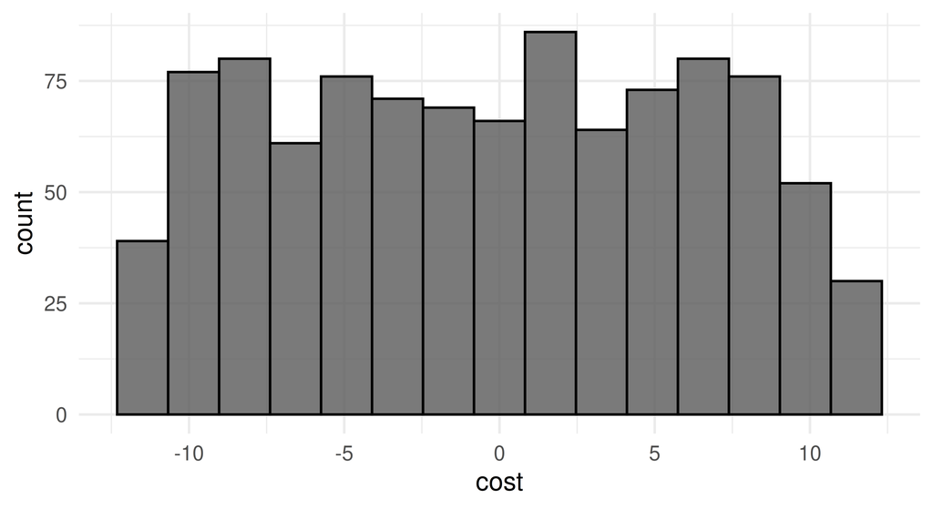

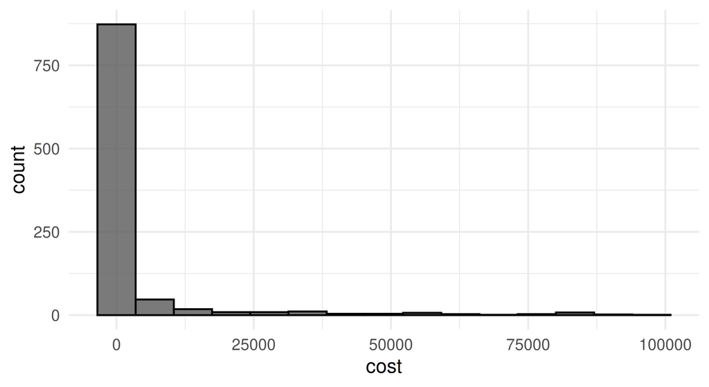

Before (left) and after log-transform (right).

```r
learner = lrn("classif.svm",
  cost  = to_tune(1e-5, 1e5, logscale = TRUE),
  gamma = to_tune(1e-5, 1e5, logscale = TRUE),
  kernel = "radial",
  type = "C-classification"
)

instance = ti(
  task = tsk_sonar,
  learner = learner,
  resampling = rsmp("cv", folds = 3),
  measures = msr("classif.ce"),
  terminator = trm("none")
)

tuner$optimize(instance)
```

Listing 2: Parameter values after tuning using a grid search and log-transform.

```
       cost     gamma learner_param_vals  x_domain classif.ce
      <num>     <num>             <list>    <list>      <num>
1: 5.756463 -5.756463          <list[4]> <list[2]>  0.1876467
```

This log-transform improved the hyperparameter search, as `classif.ce` is smaller than in Listing 1. Note that the optimal parameters shown in Listing 2 are pre-transformation. To see the values after transformation – that is, $e^x$ – use `$x_domain`.

```r
instance$result$x_domain
```

```
[[1]]
[[1]]$cost
[1] 316.2278

[[1]]$gamma
[1] 0.003162278
```

More complex transformations are discussed in Section 4.

## Analysing and using the result

We can examine all the hyperparameter configurations that were evaluated, using `$archive`.

```r
as.data.table(instance$archive)[, .(cost, gamma, classif.ce)]
```

```
          cost      gamma classif.ce
         <num>      <num>      <num>
 1: -11.512925 -11.512925  0.4661836
 2: -11.512925  -5.756463  0.4661836
 3: -11.512925   0.000000  0.4661836
 4: -11.512925   5.756463  0.4661836
 5: -11.512925  11.512925  0.4661836
---
21:   0.000000   5.756463  0.4661836
22:   0.000000  11.512925  0.4661836
23:   5.756463 -11.512925  0.2404417
24:   5.756463  11.512925  0.4661836
25:  11.512925   0.000000  0.4613527
```

Here, the columns show the tested configurations before transformation.[^7] We can also look at other features, for example, time of evaluation, model runtime and any errors or warnings.

<sup>7</sup> That is why some are negative, even though cost and gamma values must be positive. E.g. $-11.512925 \approx \log(1\times 10^{-5})$

```r
as.data.table(instance$archive)[,
  .(timestamp, runtime_learners, errors, warnings)]
```

```
              timestamp runtime_learners errors warnings
                 <POSc>            <num>  <int>    <int>
 1: 2025-04-11 11:50:24            0.017      0        0
 2: 2025-04-11 11:50:24            0.019      0        0
 3: 2025-04-11 11:50:24            0.016      0        0
 4: 2025-04-11 11:50:24            0.018      0        0
 5: 2025-04-11 11:50:24            0.015      0        0
---
21: 2025-04-11 11:50:25            0.020      0        0
22: 2025-04-11 11:50:25            0.018      0        0
23: 2025-04-11 11:50:25            0.019      0        0
24: 2025-04-11 11:50:25            0.018      0        0
25: 2025-04-11 11:50:25            0.017      0        0
```

All the resamplings combined (as a `BenchmarkResult` object) can be seen using `instance$archive$benchmark_result`

```r
instance$archive$benchmark_result
```

```
<BenchmarkResult> of 75 rows with 25 resampling runs
  nr task_id  learner_id resampling_id iters warnings errors
   1   sonar classif.svm            cv     3        0      0
   2   sonar classif.svm            cv     3        0      0
   3   sonar classif.svm            cv     3        0      0
   4   sonar classif.svm            cv     3        0      0
   5   sonar classif.svm            cv     3        0      0
 ---     ---         ---           ---   ---      ---    ---
  21   sonar classif.svm            cv     3        0      0
  22   sonar classif.svm            cv     3        0      0
  23   sonar classif.svm            cv     3        0      0
  24   sonar classif.svm            cv     3        0      0
  25   sonar classif.svm            cv     3        0      0
```

The visualisation of these results can be seen in Figure 1 (which uses [autoplot.TuningInstanceBatchSingleCrit](https://mlr3viz.mlr-org.com/reference/autoplot.TuningInstanceBatchSingleCrit.html))

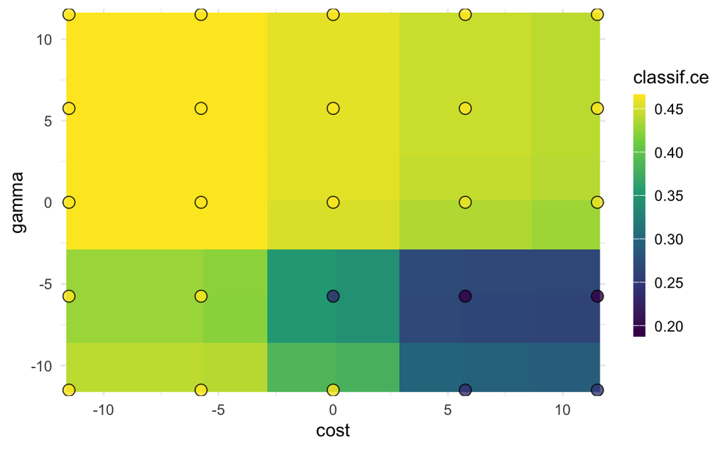

Figure 1: Model performance with different configurations for cost and gamma. Bright yellow regions represent the model performing worse and dark blue performing better.

```r
autoplot(instance, type = "surface")
```

### Training an optimised model

After we have found *good* hyperparameters for our learner through tuning, we can train the final model on the data. First, construct the learner with the ‘optimal’ hyperparameters.

```r
lrn_svm_tuned = lrn("classif.svm")
lrn_svm_tuned$param_set$values = instance$result_learner_param_vals
lrn_svm_tuned
```

```
<LearnerClassifSVM:classif.svm>: Support Vector Machine
* Model: -
* Parameters: cost=316.2, gamma=0.003162, kernel=radial,
  type=C-classification
* Packages: mlr3, mlr3learners, e1071
* Predict Types:  [response], prob
* Feature Types: logical, integer, numeric
* Properties: multiclass, twoclass
```

And then train this learner on the data.

```r
lrn_svm_tuned$train(tsk_sonar)$model
```

```
Call:
svm.default(x = data, y = task$truth(), type = "C-classification",
    kernel = "radial", gamma = 0.00316227766016838, cost = 316.227766016838,
    probability = (self$predict_type == "prob"))


Parameters:
   SVM-Type:  C-classification
 SVM-Kernel:  radial
       cost:  316.2278

Number of Support Vectors:  93
```

## Tuning with `tune` and `auto_tuner`

In Section 2 we created a tuning instance (using `ti()`), passed this to the tuner, and then called `$optimize()` to start the tuning process. There are two helper methods in `{mlr3tuning}` to simplify this process – `tune()` and `auto_tuner()`.

The `tune()` function creates the tuning instance and calls `$optimize()`. That is, it skips the step of calling `tuner$optimize(instance)`.

```r
tnr_grid_search = tnr("grid_search", resolution = 5, batch_size = 5)
lrn_svm = lrn("classif.svm",
  cost  = to_tune(1e-5, 1e5, logscale = TRUE),
  gamma = to_tune(1e-5, 1e5, logscale = TRUE),
  kernel = "radial",
  type = "C-classification"
)
rsmp_cv5 = rsmp("cv", folds = 5)
msr_ce = msr("classif.ce")

set.seed(10)
instance = mlr3tuning::tune(
  tuner = tnr_grid_search,
  task = tsk_sonar,
  learner = lrn_svm,
  resampling = rsmp_cv5,
  measures = msr_ce
)
instance$result
```

**1**

I have specificed the package here (`mlr3tuning::`), as there is also the function `e1071::tune()` and thus a namespace conflict.

```
       cost     gamma learner_param_vals  x_domain classif.ce
      <num>     <num>             <list>    <list>      <num>
1: 5.756463 -5.756463          <list[4]> <list[2]>  0.1680604
```

The equivalent code using `ti()` involves specifying the tuner instance first and then triggering it.

```r
tuner = tnr("grid_search", resolution = 5, batch_size = 5)
instance <- ti(
               task = tsk_sonar,
               learner = lrn_svm,
               resampling = rsmp_cv5,
               measures = msr_ce,
               terminator = trm("none")
               )

set.seed(10)
tuner$optimize(instance)
```

```
       cost     gamma learner_param_vals  x_domain classif.ce
      <num>     <num>             <list>    <list>      <num>
1: 5.756463 -5.756463          <list[4]> <list[2]>  0.1684088
```

```r
instance$result
```

```
       cost     gamma learner_param_vals  x_domain classif.ce
      <num>     <num>             <list>    <list>      <num>
1: 5.756463 -5.756463          <list[4]> <list[2]>  0.1684088
```

The `auto_tuner()` helper function creates an object of class [AutoTuner](https://mlr3tuning.mlr-org.com/reference/AutoTuner.html). It inherits from the `Learner` class and wraps the information needed for tuning, so that you can treat a learner waiting to be optimised just like any other learner. The `AutoTuner` runs `tune()` on the data that is passed to the model when `$train()` is called.

[figure not shown]

Illustration of an Auto-Tuner

```r
at = auto_tuner(
  tuner = tnr_grid_search,
  learner = lrn_svm,
  resampling = rsmp_cv5,
  measure = msr_ce
)

at
```

Listing 3: Initialising the `auto_tuner()`

```
<AutoTuner:classif.svm.tuned>
* Model: list
* Parameters: list()
* Packages: mlr3, mlr3tuning, mlr3learners, e1071
* Predict Types:  [response], prob
* Feature Types: logical, integer, numeric
* Properties: multiclass, twoclass
* Search Space:
       id    class     lower    upper nlevels
   <char>   <char>     <num>    <num>   <num>
1:   cost ParamDbl -11.51293 11.51293     Inf
2:  gamma ParamDbl -11.51293 11.51293     Inf
```

Now, we can call `$train()`, which will first tune the hyperparameters in the search space given in the output from Listing 3, and then fit the optimal model.

```r
set.seed(10)

split <- partition(tsk_sonar)
at$train(tsk_sonar, row_ids = split$train)
at$predict(tsk_sonar, row_ids = split$test)$score()
```

```
classif.ce
  0.173913
```

We can also look at the tuning instance, as before.

```r
at$tuning_instance
```

```
<TuningInstanceBatchSingleCrit>
* State:  Optimized
* Objective: <ObjectiveTuningBatch:classif.svm_on_sonar>
* Search Space:
       id    class     lower    upper nlevels
   <char>   <char>     <num>    <num>   <num>
1:   cost ParamDbl -11.51293 11.51293     Inf
2:  gamma ParamDbl -11.51293 11.51293     Inf
* Terminator: <TerminatorNone>
* Result:
       cost     gamma classif.ce
      <num>     <num>      <num>
1: 5.756463 -5.756463  0.1661376
* Archive:
          cost      gamma classif.ce
         <num>      <num>      <num>
 1: -11.512925  11.512925  0.5544974
 2:   0.000000   0.000000  0.5544974
 3:   5.756463 -11.512925  0.2605820
 4:  11.512925 -11.512925  0.2230159
 5:  11.512925  11.512925  0.5544974
---
21: -11.512925   5.756463  0.5544974
22:   0.000000 -11.512925  0.5544974
23:   5.756463   0.000000  0.5544974
24:   5.756463   5.756463  0.5544974
25:  11.512925  -5.756463  0.1661376
```

```r
at$tuning_instance$result
```

```
       cost     gamma learner_param_vals  x_domain classif.ce
      <num>     <num>             <list>    <list>      <num>
1: 5.756463 -5.756463          <list[4]> <list[2]>  0.1661376
```

Now, in Section 3 below will discuss *nested resampling*, which involves passing the `AutoTuner` to `resample()` and `benchmark()`.

# Nested Resampling

Analogously to *optimism* when obtaining the predictive ability of a model trained on the same data set (see Harrell et al. 2001, vol. 608, sec. 5.3.4), with HPO we also have to consider the bias due to the same data being used for determining the optimal configuration and the evaluation of the resulting model. Therefore, we need to do additional resampling to reduce this bias when evaluating the performance of a model.

Harrell, Frank E et al. 2001. *Regression Modeling Strategies: With Applications to Linear Models, Logistic Regression, and Survival Analysis*. Vol. 608. Springer.

**Nested resampling**

a method to seperate the model optimisation from the process of estimating the performance of the tuned model, using additional resampling.[^8]

<sup>8</sup> The is, while model performance is estimated using a resampling method in the ‘usual way’, tuning is then performed by resampling the resampled data

[figure not shown]

Figure 2: An illustration of nested resampling. The large blocks represent three-fold CV for the outer resampling for model evaluation and the small blocks represent four-fold CV for the inner resampling for HPO. The light blue blocks are the training sets and the dark blue blocks are the test sets.

1. Outer resampling start
   - Perform 3-fold cross-validation on the full dataset.
   - For each outer fold, split the data into:
     - Training set (light blue blocks)
     - Test set (dark blue block)
2. Inner resampling
   - Within each outer training set, perform 4-fold cross-validation.
   - These inner folds are used for tuning hyperparameters (not evaluation).
3. HPO – Hyperparameter tuning
   - Use the inner training and validation sets to evaluate different hyperparameter combinations.
   - Select the best hyperparameter configuration based on performance across inner folds.
4. Training
   - Fit the model on the entire outer training set using the tuned hyperparameters.
5. Evaluation
   - Evaluate the trained model on the outer test set (unseen during tuning).
6. Outer resampling repeats
   - Repeat steps 2–5 for each of the 3 outer folds.
7. Aggregation
   - Average the 3 outer test performance scores.
   - This gives an unbiased estimate of the model’s generalisation performance with tuning.

From the `{mlr3}` tutorial ([Section 4.3](https://mlr3book.mlr-org.com/chapters/chapter4/hyperparameter_optimization.html#sec-nested-resampling)),

> A common mistake is to think of nested resampling as a method to select optimal model configurations. Nested resampling is a method to compare models and to estimate the generalization performance of a tuned model, however, this is the performance based on multiple different configurations (one from each outer fold) and not performance based on a single configuration (Section 4.3.2). If you are interested in identifying optimal configurations, then use `tune()`/`ti()` or `auto_tuner()` with `$train()` on the complete dataset.[^9]

<sup>9</sup> **Key Point**: Nested resampling is not for selecting the “final” best hyperparameter configuration. Instead, it’s used to get an unbiased estimate of model performance after tuning — taking into account the tuning process itself.

**This is computationally intensive**

Jacob Fiksel has a [nice post](https://jfiksel.github.io/2022-01-04-missdat/) about how this can get very computationally expensive very quickly.

## Nested resampling with `AutoTuner`

Nested resampling is all altomated in `{mlr3tuning}` by passing `AutoTuner` to `resample()` or `benchmark()`.

Let’s continue with the previous example, using the auto-tuner to resample a SVC with three-fold CV in the outer resampling and four-fold CV in the inner resampling. The `tnr_grid_search` and `lrn_svm` objects were create in Section 2.6.

```r
at <- auto_tuner(
                 tuner = tnr_grid_search,
                 learner = lrn_svm,
                 resampling = rsmp("cv", folds = 4),
                 measure = msr_ce
                 )

rr <- resample(tsk_sonar, at, rsmp("cv", folds = 3), store_models = TRUE)
rr
```

**1**

Setting `store_models = TRUE` allows us to see the `AutoTuner` models (fitted on the outer training data), and also enables investigation of the inner tuning instances.

```
<ResampleResult> with 3 resampling iterations
 task_id        learner_id resampling_id iteration     prediction_test warnings
   sonar classif.svm.tuned            cv         1 <PredictionClassif>        0
   sonar classif.svm.tuned            cv         2 <PredictionClassif>        0
   sonar classif.svm.tuned            cv         3 <PredictionClassif>        0
 errors
      0
      0
      0
```

The estimated performance of the tuned model is the aggregated performance of all outer resampling iterations.

```r
rr$aggregate()
```

```
classif.ce
 0.1925466
```

The function `extract_inner_tuning_results()` and `extract_inner_tuning_archives()` return the optimal configurations (across all outer folds) and full tuning archives, respectively. There are $75$ rows for `extract_inner_tuning_archives()` as each of the 3 outer folds triggers a full 25-point grid search. Therefore, $3 \times 25 = 75$ tuning evaluations are recorded.

```r
extract_inner_tuning_results(rr)[,
  .(iteration, cost, gamma, classif.ce)]
```

```
   iteration      cost     gamma classif.ce
       <int>     <num>     <num>      <num>
1:         1  5.756463 -5.756463  0.2319328
2:         2 11.512925 -5.756463  0.2149160
3:         3  5.756463 -5.756463  0.2010504
```

```r
extract_inner_tuning_archives(rr)[,
  .(iteration, cost, gamma, classif.ce)]
```

```
    iteration       cost      gamma classif.ce
        <int>      <num>      <num>      <num>
 1:         1 -11.512925  11.512925  0.5424370
 2:         1  -5.756463 -11.512925  0.5424370
 3:         1   0.000000 -11.512925  0.5424370
 4:         1   0.000000  -5.756463  0.2972689
 5:         1  11.512925  11.512925  0.5424370
---
71:         3 -11.512925 -11.512925  0.4319328
72:         3  -5.756463 -11.512925  0.4319328
73:         3  -5.756463  -5.756463  0.4319328
74:         3   0.000000  11.512925  0.4319328
75:         3  11.512925  -5.756463  0.2010504
```

In [Section 4.3.2](https://mlr3book.mlr-org.com/chapters/chapter4/hyperparameter_optimization.html#sec-resample-overfitting), nested resampling is compared to a normal tuning technique, to show that the latter gives much more optimistically biased performance estimates.

**Summary of how to use HPO and nested resampling**

**Why use tuned hyperparameters on the full dataset?**

After tuning (e.g., via `auto_tuner()` or `tune()`), you should train your final model using all available training data. This ensures:

- The model benefits from the maximum amount of information.
- You’re using the best hyperparameters found during tuning.
- This final model is the one you’d use for deployment or making future predictions.

**Why report performance from nested resampling?**

Nested resampling gives an unbiased estimate of generalisation error because:

- The tuning is performed inside the training folds (inner resampling).
- Evaluation is done on outer test folds that were never used for tuning.
- This corrects for optimism — the bias introduced when performance is evaluated on data also used for tuning.

**Summary:**

| Step | Purpose |
| --- | --- |
| Train tuned model on full data | For final model and deployment |
| Report nested CV performance | For honest estimate of generalisation error |

# More Advanced Search Spaces

In this section, we look at the following:

- Using `to_tune()` to tune different scalar parameter classes;
- Using `ParamSet` to define your own search space (e.g. to handle tuning over vectors, transformations or handling parameter dependencies);
- Accessing a database of standardised search spaces from the literature.

## Scalar parameter tuning

The `to_tune()` function can be used to tune parameters of any class.

```r
learner = lrn("classif.svm",
  cost  = to_tune(1e-1, 1e5),
  kernel = to_tune(c("radial", "linear")),
  shrinking = to_tune(),
  type = "C-classification"
)

learner$param_set$search_space()
```

**1**

A factor, so pass the vector of levels required.

**2**

A logical, which `to_tune()` recognises automatically.

```
<ParamSet(3)>
          id    class lower upper nlevels        default  value
      <char>   <char> <num> <num>   <num>         <list> <list>
1:      cost ParamDbl   0.1 1e+05     Inf <NoDefault[0]> [NULL]
2:    kernel ParamFct    NA    NA       2 <NoDefault[0]> [NULL]
3: shrinking ParamLgl    NA    NA       2           TRUE [NULL]
```

Numerical parameters can also be treated as factors if we want to discretise them over a small subset of possible values. For example;

```r
lrn("classif.ranger", num.trees = to_tune(c(100, 200, 400)))
```

## Defining Search Spaces with `ps`

The helper function `to_tune()` creates a parameter set that is then used by `tune()`, `ti()` or `auto_tuner()`. However, sometimes you will need to create a parameter set manually using `ps()`. This function takes names arguments of class `Domain`, which can be create using the sugar functions in the table below.

`Domain` constructors and their resulting `Domain`.

| Constructor | Description | Underlying Class |
| --- | --- | --- |
| `p_dbl` | Real valued parameter (“double”) | `ParamDbl` |
| `p_int` | Integer parameter | `ParamInt` |
| `p_fct` | Discrete valued parameter (“factor”) | `ParamFct` |
| `p_lgl` | Logical / Boolean parameter | `ParamLgl` |
| `p_uty` | Untyped parameter | `ParamUty` |

A simple example: create a search space to tune `cost` `kernel` and `shrinking`,

```r
search_space = ps(
                  cost = p_dbl(lower = 1e-1, upper = 1e5),
                  kernel = p_fct(c("radial", "linear")),
                  shrinking = p_lgl()
                  )
```

We then pass this search space into `ti()`.

```r
ti(
   tsk_sonar,
   lrn("classif.svm", type = "C-classification"),
   rsmp("cv", folds = 3),
   msr_ce,
   trm("none"),
   search_space = search_space
   )
```

```
<TuningInstanceBatchSingleCrit>
* State:  Not optimized
* Objective: <ObjectiveTuningBatch:classif.svm_on_sonar>
* Search Space:
          id    class lower upper nlevels
      <char>   <char> <num> <num>   <num>
1:      cost ParamDbl   0.1 1e+05     Inf
2:    kernel ParamFct    NA    NA       2
3: shrinking ParamLgl    NA    NA       2
* Terminator: <TerminatorNone>
```

For creating more advanced search spaces, see [Section 4.4.3](https://mlr3book.mlr-org.com/chapters/chapter4/hyperparameter_optimization.html#sec-tune-trafo) (*Transformations and Tuning Over Vectors*)[^10], and [Section 4.4.5](https://mlr3book.mlr-org.com/chapters/chapter4/hyperparameter_optimization.html#sec-tuning-spaces) for using `{mlr3tuningspaces}` to providing implementations of published search spaces for many popular machine learning algorithms.

<sup>10</sup> This section considers different transformations of parameters, and scenarios where hyperparameters are interdependent or need to be transformed jointly. For instance, when tuning a support vector machine (SVM), the cost and gamma parameters often require simultaneous optimization due to their combined effect on model performance.

# Conclusion

Important classes and functions covered in this chapter with underlying class (if applicable), class constructor or function, and important class fields and methods (if applicable).

| Class | Constructor/Function | Fields/Methods |
| --- | --- | --- |
| `Terminator` | `trm()` | – |
| `TuningInstanceBatchSingleCrit` or `TuningInstanceBatchMultiCrit` | `ti()` / `tune()` | `$result`; `$archive` |
| `TunerBatch` | `tnr()` | `$optimize()` |
| `TuneToken` | `to_tune()` | – |
| `AutoTuner` | `auto_tuner()` | `$train()`; `$predict()`; `$tuning_instance` |
| – | `extract_inner_tuning_results()` | – |
| – | `extract_inner_tuning_archives()` | – |
| `ParamSet` | `ps()` | – |
| `TuningSpace` | `lts()` | `$values` |

# Exercises

1. Tune the `mtry`, `sample.fraction`, and `num.trees` hyperparameters of `lrn("regr.ranger")` on `tsk("mtcars")`. Use a simple random search with 50 evaluations. Evaluate with a 3-fold CV and the root mean squared error. Visualize the effects that each hyperparameter has on the performance via simple marginal plots, which plot a single hyperparameter versus the cross-validated MSE.
2. Evaluate the performance of the model created in Exercise 1 with nested resampling. Use a holdout validation for the inner resampling and a 3-fold CV for the outer resampling.
3. Tune and benchmark an XGBoost model against a logistic regression (without tuning the latter) and determine which has the best Brier score. Use `mlr3tuningspaces` and nested resampling, try to pick appropriate inner and outer resampling strategies that balance computational efficiency vs. stability of the results.
4. (*) Write a function that implements an iterated random search procedure that drills down on the optimal configuration by applying random search to iteratively smaller search spaces. Your function should have seven inputs: `task`, `learner`, `search_space`, `resampling`, `measure`, `random_search_stages`, and `random_search_size`. You should only worry about programming this for fully numeric and bounded search spaces that have no dependencies. In pseudo-code:

## Question 1

Tune the `mtry`, `sample.fraction`, and `num.trees` hyperparameters of `lrn("regr.ranger")` on `tsk("mtcars")`. Use a simple random search with 50 evaluations. Evaluate with a 3-fold CV and the root mean squared error. Visualize the effects that each hyperparameter has on the performance via simple marginal plots, which plot a single hyperparameter versus the cross-validated MSE.

### Answer

Let’s load the task and look at the properties of the `mtry`, `sample.fraction`, and `num.trees` parameters.

```r
tsk_mtcars <- tsk("mtcars")
lrn("regr.ranger")$param_set$data[id %in% c("mtry", "sample.fraction", "num.trees")]
```

```
                id    class lower upper levels nlevels is_bounded special_vals
            <char>   <char> <num> <num> <list>   <num>     <lgcl>       <list>
1:            mtry ParamInt     1   Inf [NULL]     Inf      FALSE    <list[1]>
2:       num.trees ParamInt     1   Inf [NULL]     Inf      FALSE    <list[0]>
3: sample.fraction ParamDbl     0     1 [NULL]     Inf       TRUE    <list[0]>
          default storage_type                   tags
           <list>       <char>                 <list>
1: <NoDefault[0]>      integer                  train
2:            500      integer train,predict,hotstart
3: <NoDefault[0]>      numeric                  train
```

The hyperparameters I’m looking at are:

- `mtry`: number of variables considered at each tree split.
- `num.trees`: number of trees in the forest.
- `sample.fraction`: fraction of observations used to train each tree.

Now I will set up the tuning of the `mtry`, `sample.fraction`, and `num.trees` hyperparameters.

```r
learner <- lrn("regr.ranger",
               mtry = to_tune(p_int(1, 10)),
               num.trees = to_tune(20, 2000),
               sample.fraction = to_tune(0.1, 1))
learner
```

```
<LearnerRegrRanger:regr.ranger>: Random Forest
* Model: -
* Parameters: mtry=<ObjectTuneToken>, num.threads=1,
  num.trees=<RangeTuneToken>, sample.fraction=<RangeTuneToken>
* Packages: mlr3, mlr3learners, ranger
* Predict Types:  [response], se, quantiles
* Feature Types: logical, integer, numeric, character, factor, ordered
* Properties: hotstart_backward, importance, missings, oob_error,
  selected_features, weights
```

Setting up an instance to terminate the tuner after 50 evaluations, and to use 3-fold CV.

```r
instance <- ti(task = tsk_mtcars,
               learner = learner,
               resampling = rsmp("cv", folds = 3),
               # rmse gives interpretability in the original units (MPG) rather than squared units
               measures = msr("regr.rmse"),
               terminator = trm("evals", n_evals = 50))
instance
```

```
<TuningInstanceBatchSingleCrit>
* State:  Not optimized
* Objective: <ObjectiveTuningBatch:regr.ranger_on_mtcars>
* Search Space:
                id    class lower upper nlevels
            <char>   <char> <num> <num>   <num>
1:            mtry ParamInt   1.0    10      10
2:       num.trees ParamInt  20.0  2000    1981
3: sample.fraction ParamDbl   0.1     1     Inf
* Terminator: <TerminatorEvals>
```

The tuning step uses 3-fold cross-validation:

- In each evaluation, two-thirds of the data is used for training,
- One-third is used for validation (i.e. to compute the RMSE).
- This is repeated for 50 random configurations (as specified by the terminator).

Now I can set up the tuning process (random search).

```r
tuner <- tnr("random_search")
#tuner$param_set
tuner
```

```
<TunerBatchRandomSearch>: Random Search
* Parameters: batch_size=1
* Parameter classes: ParamLgl, ParamInt, ParamDbl, ParamFct
* Properties: dependencies, single-crit, multi-crit
* Packages: mlr3tuning, bbotk
```

And trigger the tuning process.

```r
set.seed(333)
tuner$optimize(instance)
```

```
    mtry num.trees sample.fraction learner_param_vals  x_domain regr.rmse
   <int>     <int>           <num>             <list>    <list>     <num>
1:    10      1283       0.8781863          <list[4]> <list[3]>  2.749842
```

```r
instance$result
```

```
    mtry num.trees sample.fraction learner_param_vals  x_domain regr.rmse
   <int>     <int>           <num>             <list>    <list>     <num>
1:    10      1283       0.8781863          <list[4]> <list[3]>  2.749842
```

```r
instance$result$learner_param_vals
```

```
[[1]]
[[1]]$num.threads
[1] 1

[[1]]$mtry
[1] 10

[[1]]$num.trees
[1] 1283

[[1]]$sample.fraction
[1] 0.8781863
```

All 50 of the random search evaluations are stored in the `archive` slot of the `instance` object.

```r
as.data.table(instance$archive)[, .(mtry, sample.fraction, num.trees, regr.rmse)]
```

```
     mtry sample.fraction num.trees regr.rmse
    <int>           <num>     <int>     <num>
 1:     5       0.9761367       187  2.785571
 2:     8       0.3760474      1227  3.368686
 3:     4       0.9020999       959  2.778808
 4:    10       0.8781863      1283  2.749842
 5:     2       0.2718788       161  6.168044
---
46:     9       0.2032898       720  6.104461
47:     7       0.6087772        35  3.085625
48:     4       0.1445110      1487  6.131323
49:     6       0.7125770      1637  2.791505
50:     3       0.1578512       302  6.248784
```

Now let’s visualise the effect of each hyperparameter using marginal plots.

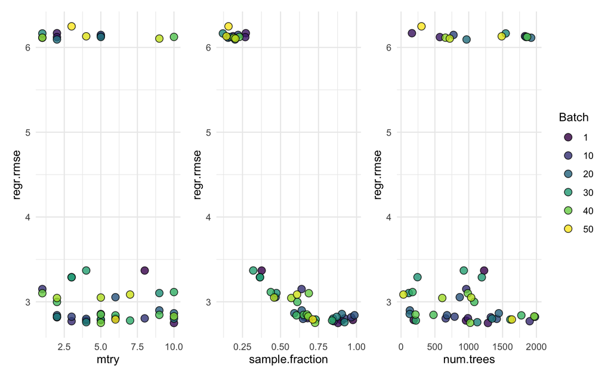

```r
autoplot(instance, type = "marginal", cols_x = c("mtry", "sample.fraction", "num.trees"))
```

As during the HPO stage, I used 3-fold CV, the model has not seen the full data all at once. So, now I’ll train the model using the optimised hyperparameters.

```r
lrn_ranger_tuned <- lrn("regr.ranger")
lrn_ranger_tuned$param_set$values = instance$result_learner_param_vals
lrn_ranger_tuned$train(tsk_mtcars)$model
```

```
Ranger result

Call:
 ranger::ranger(dependent.variable.name = task$target_names, data = task$data(),      case.weights = task$weights$weight, mtry = 10L, num.threads = 1L,      num.trees = 1283L, sample.fraction = 0.878186269127764)

Type:                             Regression
Number of trees:                  1283
Sample size:                      32
Number of independent variables:  10
Mtry:                             10
Target node size:                 5
Variable importance mode:         none
Splitrule:                        variance
OOB prediction error (MSE):       5.843943
R squared (OOB):                  0.8391167
```

**Summary of question 1 (hyperparameter tuning with random search)**

I tuned the `regr.ranger` learner on the `mtcars` dataset, focusing on three hyperparameters:

- `mtry`: number of variables considered at each split,
- `num.trees`: number of trees in the forest,
- `sample.fraction`: fraction of the dataset used for each tree.

**Steps I took:**

## Question 2

Evaluate the performance of the model created in Exercise 1 with nested resampling. Use a holdout validation for the inner resampling and a 3-fold CV for the outer resampling.

### Answer

OK, so here we need an outer and inner resampling strategy. The outer resampling strategy will be a 3-fold CV, and the inner resampling strategy will be a holdout validation.

[figure not shown]

Figure 3: An illustration of nested resampling. The large blocks represent 3-fold CV for the outer resampling for model evaluation and the small blocks represent 4-fold CV for the inner resampling for HPO. The light blue blocks are the training sets and the dark blue blocks are the test sets.

Figure 3 shows an example of a nest resampling strategy (with 3-fold CV on the outer and 4-fold CV on the inner nest). Here, we need to do something slightly different as we are using the holdout resampling strategy on the inner nest.

1. Outer resampling start
   - Perform 3-fold cross-validation on the full dataset.
   - For each outer fold, split the data into:
     - Training set (light blue blocks)
     - Test set (dark blue block)
2. Inner resampling
   - Within each outer training set, perform holdout validation (assuming 70/30 training-test split).
   - This inner split is used for tuning hyperparameters (not evaluation).
3. HPO – Hyperparameter tuning
   - Evaluate different hyperparameter combinations by fitting models on the inner training set and evaluating performance on the inner validation (holdout) set.
   - Select the best hyperparameter configuration based on performance on the inner holdout set.
4. Training
   - Fit the model on the entire outer training set using the tuned hyperparameters.
5. Evaluation
   - Evaluate the trained model on the outer test set (unseen during tuning).
6. Outer resampling repeats
   - Repeat steps 2–5 for each of the 3 outer folds.
7. Aggregation
   - Average the 3 outer test performance scores.
   - This gives an unbiased estimate of the model’s generalisation performance with tuning.

I will use `AutoTuner` to do nested resampling, as that is what is done in [Section 4.3.1](https://mlr3book.mlr-org.com/chapters/chapter4/hyperparameter_optimization.html#sec-nested-resampling) of the mlr3 tutorial.

```r
## create auto_tuner to resample a random forest
# with 3-fold CV in outer resampling and
# holdout validation in inner resampling
at <- auto_tuner(
         tuner = tnr("random_search"),
         learner = lrn("regr.ranger",
                       mtry = to_tune(1, 1e1),
                       num.trees = to_tune(1, 1e5),
                       sample.fraction = to_tune(0.1, 1)),
         # inner resampling
         resampling = rsmp("holdout", ratio = 0.7),
         measure = msr("regr.rmse"),
         terminator = trm("evals", n_evals = 50)
        )

# resampling step
rr <- resample(tsk("mtcars"),
               at,
               # outer resampling
               rsmp("cv", folds = 3),
               store_models = TRUE)

rr
```

**1**

**2**

Set `store_models = TRUE` so that the `AutoTuner` models (fitted on the outer training data) are stored,

```
<ResampleResult> with 3 resampling iterations
 task_id        learner_id resampling_id iteration  prediction_test warnings
  mtcars regr.ranger.tuned            cv         1 <PredictionRegr>        0
  mtcars regr.ranger.tuned            cv         2 <PredictionRegr>        0
  mtcars regr.ranger.tuned            cv         3 <PredictionRegr>        0
 errors
      0
      0
      0
```

Now I aggregate across the three outer folds to get the final performance.

```r
rr$aggregate()
```

```
regr.mse
13.13362
```

The inner tuning results can also be accessed, returning the optimal configurations (across all outer folds) and the full tuning archives.

```r
# optimal configurations
extract_inner_tuning_results(rr)
```

```
   iteration  mtry num.trees sample.fraction regr.rmse learner_param_vals
       <int> <int>     <int>           <num>     <num>             <list>
1:         1     1     81784       0.6769030  2.884958          <list[4]>
2:         2     5     73924       0.9194928  2.065022          <list[4]>
3:         3     3     15719       0.7797092  1.807826          <list[4]>
    x_domain task_id        learner_id resampling_id
      <list>  <char>            <char>        <char>
1: <list[3]>  mtcars regr.ranger.tuned            cv
2: <list[3]>  mtcars regr.ranger.tuned            cv
3: <list[3]>  mtcars regr.ranger.tuned            cv
```

```r
# full tuning archives
extract_inner_tuning_archives(rr)
```

```
     iteration  mtry num.trees sample.fraction regr.rmse x_domain_mtry
         <int> <int>     <int>           <num>     <num>         <int>
  1:         1     2     15547       0.3219244  5.115809             2
  2:         1     8     23468       0.3020848  5.113502             8
  3:         1     5     47564       0.3500007  5.115646             5
  4:         1     9     14922       0.8105999  3.261807             9
  5:         1     2     81447       0.1308460  5.124990             2
 ---
146:         3     5     20556       0.5608060  2.081965             5
147:         3     2      9179       0.8461799  1.867438             2
148:         3     4     93847       0.1486419  3.733662             4
149:         3     3     15719       0.7797092  1.807826             3
150:         3     1     31967       0.2513883  3.739324             1
     x_domain_num.trees x_domain_sample.fraction runtime_learners
                  <int>                    <num>            <num>
```

[output cut: 37 more lines]

**Summary of question 2 (nested resampling)**

I evaluated the performance of the tuned model using nested resampling to obtain an unbiased estimate.

**Steps I took:**

## Question 3

Tune and benchmark an XGBoost model against a logistic regression (without tuning the latter) and determine which has the best Brier score. Use `mlr3tuningspaces` and nested resampling, try to pick appropriate inner and outer resampling strategies that balance computational efficiency vs. stability of the results.

### Answer

I’ll use the built-in `spam` task – since the outcome is categorical, this is a classification task.

```r
tsk_spam <- tsk("spam")
```

First I’ll set up the logistic regression model (with no tuning).

```r
# requires probs to compute the brier score
lrn_logreg <- lrn("classif.log_reg", predict_type = "prob")
```

The XGBoost model has lots of hyperparameters:

```r
lrn("classif.xgboost")$param_set$ids()
```

```
 [1] "alpha"                       "approxcontrib"
 [3] "base_score"                  "booster"
 [5] "callbacks"                   "colsample_bylevel"
 [7] "colsample_bynode"            "colsample_bytree"
 [9] "device"                      "disable_default_eval_metric"
[11] "early_stopping_rounds"       "eta"
[13] "eval_metric"                 "feature_selector"
[15] "gamma"                       "grow_policy"
[17] "interaction_constraints"     "iterationrange"
[19] "lambda"                      "lambda_bias"
[21] "max_bin"                     "max_delta_step"
[23] "max_depth"                   "max_leaves"
[25] "maximize"                    "min_child_weight"
[27] "missing"                     "monotone_constraints"
[29] "nrounds"                     "normalize_type"
```

[output cut: 16 more lines]

The main ones are:

| Hyperparameter | Description | Type |
| --- | --- | --- |
| `eta` | Learning rate (shrinkage) | numeric |
| `max_depth` | Maximum depth of trees | integer |
| `nrounds` | Number of boosting rounds (trees) | integer |
| `colsample_bytree` | Fraction of features randomly sampled per tree | numeric |
| `subsample` | Fraction of rows sampled per tree | numeric |
| `min_child_weight` | Minimum sum of instance weights in a child node | numeric |
| `gamma` | Minimum loss reduction to make a split | numeric |
| `lambda` | L2 regularisation term on weights | numeric |
| `alpha` | L1 regularisation term on weights | numeric |

A typical tuning strategy for XGBoost might involve:

1. Starting with basic tree shape and learning rate:
   - `max_depth`
   - `eta`
   - `nrounds`
2. Adding sampling and regularisation to control overfitting:
   - `subsample`
   - `colsample_bytree`
   - `min_child_weight`
   - `gamma`
3. Fine-tuning regularisation terms if needed:
   - `lambda` (L2)
   - `alpha` (L1)

For the XGBoost learner, I’m going to use a predefined search space from `{mlr3tuningspaces}`. First, I’ll give a list of these predefined spaces.

```r
mlr_tuning_spaces$keys()[grepl("xgboost", mlr_tuning_spaces$keys())]
```

```
[1] "classif.xgboost.default" "classif.xgboost.rbv1"
[3] "classif.xgboost.rbv2"    "regr.xgboost.default"
[5] "regr.xgboost.rbv1"       "regr.xgboost.rbv2"
```

I will use the `classif.xgboost.default` space.

```r
space = lts("classif.xgboost.default")
space
```

```
<TuningSpace:classif.xgboost.default>: Classification XGBoost with Default
                  id lower upper levels logscale
              <char> <num> <num> <list>   <lgcl>
1:               eta 1e-04     1 [NULL]     TRUE
2:           nrounds 1e+00  5000 [NULL]    FALSE
3:         max_depth 1e+00    20 [NULL]    FALSE
4:  colsample_bytree 1e-01     1 [NULL]    FALSE
5: colsample_bylevel 1e-01     1 [NULL]    FALSE
6:            lambda 1e-03  1000 [NULL]     TRUE
7:             alpha 1e-03  1000 [NULL]     TRUE
8:         subsample 1e-01     1 [NULL]    FALSE
```

```r
# create terminator with time budget of 5 secs
trm_rt = trm("run_time")
trm_rt$param_set$values$secs = 5

# create xgboost learner with prob predict_type
# 'prob' required for brier score
lrn_xgb = lrn("classif.xgboost", predict_type = "prob")

at_xgb <- auto_tuner(learner = lrn_xgb,
                    resampling = rsmp("cv", folds = 5),
                    measure = msr("classif.bbrier"),
                    terminator = trm_rt,
                    tuner = tnr("random_search"),
                    search_space = space)
at_xgb
```

```
<AutoTuner:classif.xgboost.tuned>
* Model: list
* Parameters: list()
* Packages: mlr3, mlr3tuning, mlr3learners, xgboost
* Predict Types:  response, [prob]
* Feature Types: logical, integer, numeric
* Properties: hotstart_forward, importance, missings, multiclass,
  offset, twoclass, weights
* Search Space:
                  id    class     lower       upper nlevels
              <char>   <char>     <num>       <num>   <num>
1:             alpha ParamDbl -6.907755    6.907755     Inf
2: colsample_bylevel ParamDbl  0.100000    1.000000     Inf
3:  colsample_bytree ParamDbl  0.100000    1.000000     Inf
4:               eta ParamDbl -9.210340    0.000000     Inf
5:            lambda ParamDbl -6.907755    6.907755     Inf
6:         max_depth ParamInt  1.000000   20.000000      20
7:           nrounds ParamInt  1.000000 5000.000000    5000
8:         subsample ParamDbl  0.100000    1.000000     Inf
```

Now I can set up the outer resampling strategy (4-fold CV).

```r
outer_rsmp <- rsmp("cv", folds = 4)
```

I can create a benchmark grid and run it for the task to compare the two learners.

```r
# Benchmark both learners
design = benchmark_grid(
  tasks = tsk_spam,
  learners = list(lrn_logreg, at_xgb),
  resamplings = outer_rsmp
)
design
```

```
     task               learner resampling
   <char>                <char>     <char>
1:   spam       classif.log_reg         cv
2:   spam classif.xgboost.tuned         cv
```

```r
# run the benchmark design
set.seed(101)
bmr = benchmark(design)
# the score for each of the 4-fold CV outer folds
bmr$score(msr("classif.bbrier"))[,
         .(learner_id, resampling_id, iteration, classif.bbrier)
         ]
```

```
              learner_id resampling_id iteration classif.bbrier
                  <char>        <char>     <int>          <num>
1:       classif.log_reg            cv         1     0.06236199
2:       classif.log_reg            cv         2     0.05802780
3:       classif.log_reg            cv         3     0.05744753
4:       classif.log_reg            cv         4     0.05651042
5: classif.xgboost.tuned            cv         1     0.06579101
6: classif.xgboost.tuned            cv         2     0.02612072
7: classif.xgboost.tuned            cv         3     0.04300883
8: classif.xgboost.tuned            cv         4     0.17787564
```

```r
# the aggregate score for each learner
bmr$aggregate(msr("classif.bbrier"))[,
         .(learner_id, resampling_id, classif.bbrier)
         ]
```

```
              learner_id resampling_id classif.bbrier
                  <char>        <char>          <num>
1:       classif.log_reg            cv     0.05858693
2: classif.xgboost.tuned            cv     0.07819905
```

I can use `autoplot` to plot these results.

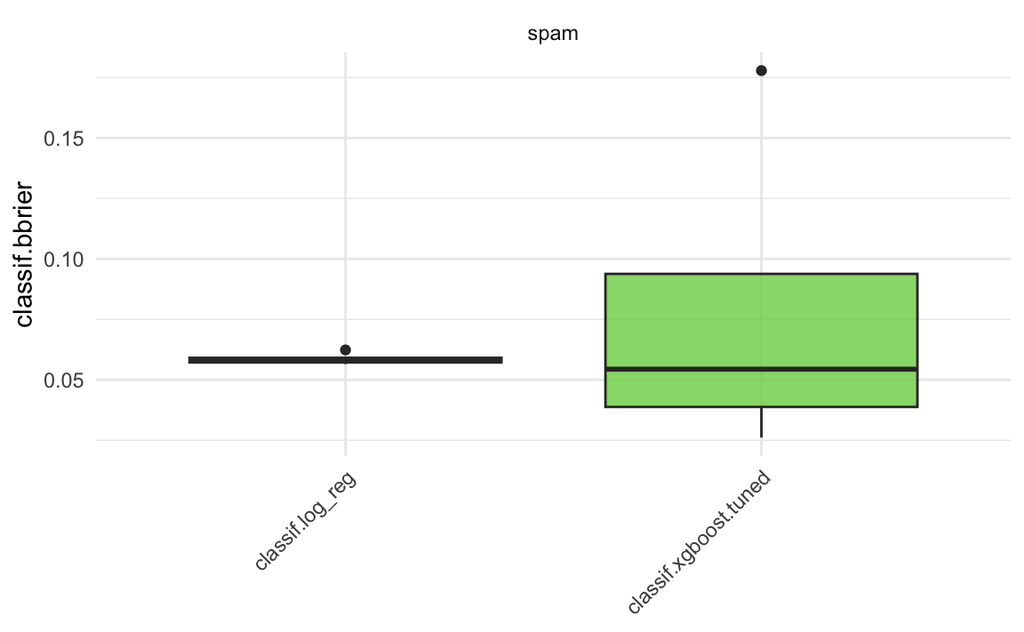

```r
autoplot(bmr, measure = msr("classif.bbrier"))
```

**Summary of question 3 (XGBoost vs. logistic regression)**

I benchmarked a tuned XGBoost model against an untuned logistic regression model on the `spam` classification task using the Brier score.

**Steps I took:**

## Question 4

Write a function that implements an iterated random search procedure that drills down on the optimal configuration by applying random search to iteratively smaller search spaces. Your function should have seven inputs: `task`, `learner`, `search_space`, `resampling`, `measure`, `random_search_stages`, and `random_search_size`. You should only worry about programming this for fully numeric and bounded search spaces that have no dependencies. In pseudo-code:

[output not shown]

### Answer

Let’s start by trying this out on the `mtcars` dataset, using the `regr.rpart` learner. First, I’ll load the task and learner, and then look at the hyperparameters of this learner.

```r
task <- tsk("mtcars")
learner <- lrn("regr.rpart")
# look at the hyperparameters
as.data.table(learner$param_set)[, .(id, class, lower, upper)]
```

```
                id    class lower upper
            <char>   <char> <num> <num>
 1:             cp ParamDbl     0     1
 2:     keep_model ParamLgl    NA    NA
 3:     maxcompete ParamInt     0   Inf
 4:       maxdepth ParamInt     1    30
 5:   maxsurrogate ParamInt     0   Inf
 6:      minbucket ParamInt     1   Inf
 7:       minsplit ParamInt     1   Inf
 8: surrogatestyle ParamInt     0     1
 9:   usesurrogate ParamInt     0     2
10:           xval ParamInt     0   Inf
```

Common hyperparameters to tune for `regr.rpart` learner.

| ID | Description | Typical Range | Notes |
| --- | --- | --- | --- |
| `cp` | Complexity parameter: controls cost of adding splits | [0.001, 0.1] (log-scale) | Lower values allow deeper trees |
| `maxdepth` | Maximum depth of the tree | 1–30 | Prevents trees from growing too deep |
| `minsplit` | Minimum number of observations required to attempt a split | 2–20 | Higher values make trees more conservative |
| `minbucket` | Minimum number of observations in any terminal node | 1–10 | If not set, defaults to `minsplit / 3` |

I’ll now create a search space to tune the four hyperparameters `cp`, `maxdepth`, `minsplit`, and `minbucket`.

```r
search_space <- ps(
  cp = p_dbl(lower = 0.001, upper = 0.1, logscale = TRUE),
  maxdepth = p_int(lower = 1, upper = 30),
  minsplit = p_int(lower = 2, upper = 20),
  minbucket = p_int(lower = 1, upper = 10)
)
```

# Summary

Great. Let’s summarise what I’ve done in this post.

**Exercise 1: Hyperparameter Tuning with Random Search**

**Exercise 2: Nested Resampling**

**Exercise 3: Benchmarking XGBoost vs Logistic Regression**